# Les ventes de livres de 2010 à 2019 dans la region de Montreal

Danae Martinez

Dernière mise à jour: 19 August 2020

# 1 Introduction

## 1.1 Presentation des donnees

Nous avons a notre disposition l’historique de ventes de livres de 2010 a 2019 au Quebec par region en par categorie.

## 1.2 Description de variables

1. Date: du premier janvier 2010 jusqu’au 31 decembre 2019
2. Categorie: faisant referenace a la categorie du livre:

Bande dessinée, Beaux-arts, Biographies, Dictionnaires et références, Économie, gestion et droit, Éducation, Ésotérisme et sciences occultes, Géographie et tourisme, Histoire, Informatique, Jeunesse, Langues, communication et médias, Littérature, Parascolaire, Politique et administration publique, Religion et spiritualité, Sciences et médecine, Sciences humaines et sociales, Scolaire, Sports, Techniques, Vie pratique.

3. Region: faisant reference aux region du Quebec Dans cette analyse, nous nous limiterons a l’analyse de la region de Montréal
4. Quantite de livres vendus, volume de ventes
5. Montant, volume de ventes en dollars

# 2 Analyse descriptive de l’historique de ventes

Cette analyse a pour but d’explorer le comportement historique de ventes de livres dans la région de Montréal.

## 2.1 Ventes annuelles depuis 2010

Le graphique suivant montre le montant vendu par année entre 2010 et 2019 à Montréal.

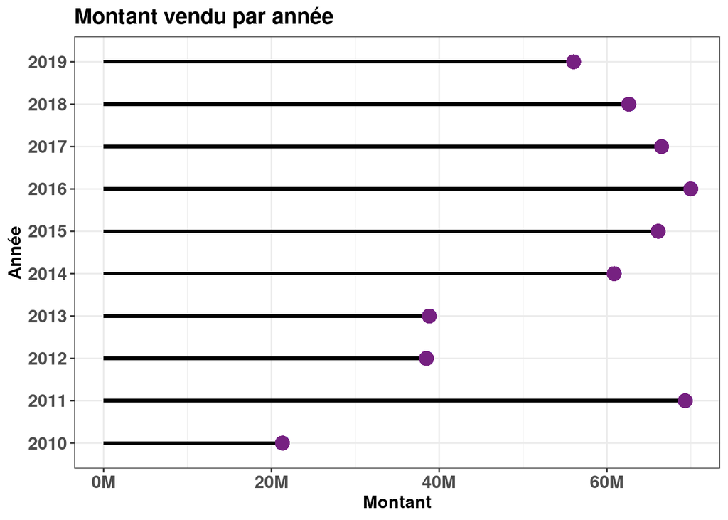

Les ventes de livres ont reculé de 44,5% en 2012, après avoir connu une hausse de 225,27% en 2011.

On observe une tendence a la baisse depuis 2017 ou les ventes on recule de -4.9%. En 2018 on a observe une baisse de %-5.8, pour finir avec une recul de -10.5 en 2019.

On observe que l’année la plus profitable fut 2016. On observe également que les six dernières années ont été semblables en termes de chiffres annuels. Cependant, il y a une tendance à la baisse depuis 2016. On également remarque que l’année 2011 présente un chiffre de ventes particulièrement haut par rapport aux restes d’années.

## 2.2 Ventes mensuels depuis 2010

Nous voudrions avoir plus d’informations concernant le volume des ventes historiques. Le graphique ci-dessous montre les tendances historiques des ventes mensuelles.

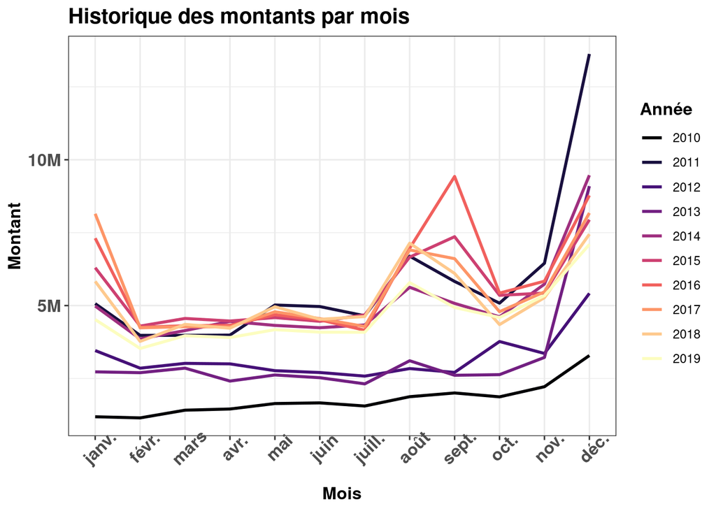

Remarquons que c’est le mois décembre 2011 qui a le record des ventes historiques, suivi de septembre 2016. De façon plus générale, on observe que les trois périodes de pointe sont au mois d’août, au mois de décembre et au mois de janvier.

Le Salon du livre de Montréal a lieu au mois de novembre. Nous aimerions savoir si cet événement a un effet sur les ventes. À première vue il n’est pas évident d’affirmer un effet immédiat, mais on essaie de savoir s’il y a des répercussions sur les semaines suivantes à l’événement.

Les tables suivantes montrent les mois avec plus de ventes pour l’année 2019 dans la région de Montréal.

## 2.3 Mois avec plus de ventes

Montréal 2019

| mois | montant (%) | montant | quantité (%) | quantité |
| --- | --- | --- | --- | --- |
| Décembre | 12.67 | 7096047 | 12.87 | 439675 |
| Août | 10.33 | 5786234 | 10.43 | 356349 |
| Novembre | 9.54 | 5341649 | 9.73 | 332495 |
| Septembre | 8.81 | 4934542 | 7.62 | 260138 |
| Octobre | 8.20 | 4591373 | 8.23 | 281182 |
| Janvier | 8.07 | 4520301 | 6.56 | 224065 |

Les mois avec plus des ventes sont décembre, août, septembre et janvier (période de rentrée scolaire et temps de fêtes), mais on observe que le mois de novembre se trouve parmi les mois avec les plus hautes ventes.

## 2.4 Ventes hedomadaires depuis 2010

Essayons d’aller à un niveau plus détaillé, puis regardons le comportement des ventes par semaine, ici les semaines ont été numérotées de 1 à 52.

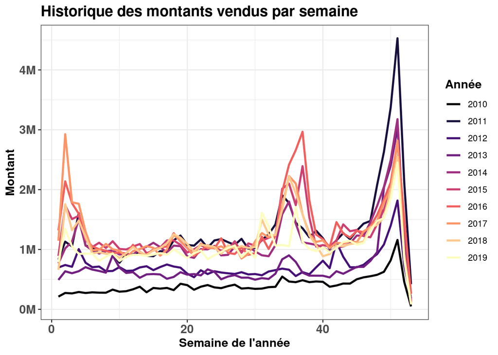

On observe trois périodes de pointe. Est-ce les deux rentrées scolaires et le temps de fêtes?

## 2.5 Ventes quotidiens depuis 2010

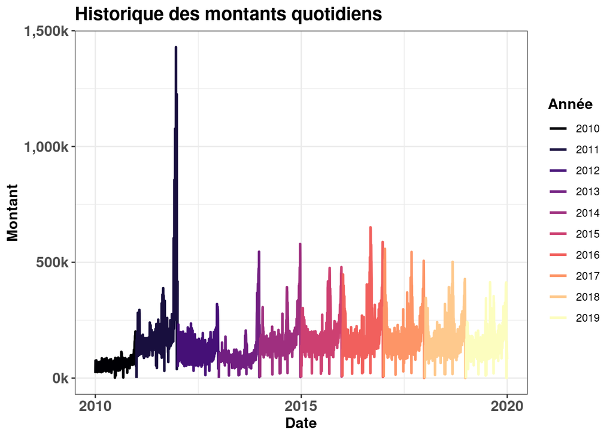

L’année 2011 est une année avec un comportement atypique. À partir 2013 le comportement des séries semble à être plus stable. C’est pour quoi nous allons considérer l’historique à partir 2013 dans les analyses à venir. Remarquons également la présence d’un comportement saisonnière.

# 3 References:

1. [Banque de données des statistiques officielles sur le Québec](https://bdso.gouv.qc.ca/pls/ken/ken263_rechr_base.page_reslt)
2. [Institut de la statistique Quebec](https://www.stat.gouv.qc.ca/statistiques/culture/livre/vente/index.html)